# Supervised Learning II

Hyperparameter Tuning

# Goal

After this exercise, you should be able to define search spaces for learning algorithms and apply different hyperparameter (HP) optimization (HPO) techniques to search through the search space to find a well-performing hyperparameter configuration (HPC).

# Exercises

Again, we are looking at the `german_credit` data set and corresponding task (you can quickly load the task with `tsk("german_credit")`). We want to train a k-NN model but ask ourselves what the best choice of $k$ might be? Furthermore, we are not sure how to set other HPs of the learner, e.g., if we should scale the data or not. In this exercise, we conduct HPO for k-NN to automatically find a good HPC.

```r
library(mlr3verse)
task = tsk("german_credit")
```

**Recap**

k-NN is a machine learning method that predicts new data by averaging over the responses of the k nearest neighbors.

## Parameter spaces

Define a meaningful search space for the HPs `k` and `scale`. You can checkout the help page `lrn("classif.kknn")$help()` for an overview of the k-NN learner.

**Hint 1**

Each learner has a slot `param_set` that contains all HPs that can be used for the tuning. In this use case we tune a learner with the key `"classif.kknn"`. The functions to define the search space are `ps` and `p_int`, `p_dbl`, `p_fct`, or `p_lgl` for HPs in the search space.

**Hint 2**

```r
library(mlr3tuning)

search_space = ps(
  k = p_int(...),
  scale = ...
)
```

### Solution

**Click me**

```r
library(mlr3tuning)

search_space = ps(
  k = p_int(1, 100),
  scale = p_lgl()
)
```

## Hyperparameter optimization

Now, we want to tune the k-NN model with the search space from the previous exercise. As resampling strategy we use a 3 fold cross validation. The tuning strategy should be a random search. As termination criteria we choose 40 evaluations.

**Hint 1**

The elements required for the tuning are:

- Task: German credit
- Algorithm: k-NN algorithm from `lrn()`
- Resampling: 3-fold cross validation using `rsmp()`
- Terminator: 40 evaluations using `trm()`
- Search space: See previous exercise
- We use the default performance measure (`msr("classif.ce")` for classification and `msr("classif.mse")` for regression)

The tuning instance is then defined by calling `TuningInstanceSingleCrit$new()`. The random search optimization algorithm is obtained from `tnr()` with the corresponding key as argument. Furthermore, we allow parallel computations and set the batch size as well as the number of cores to four.

**Hint 2**

The optimization algorithm is obtained from `tnr()` with the corresponding key as argument. Furthermore we allow parallel computations using four cores:

```r
library(mlr3)
library(mlr3learners)
library(mlr3tuning)

future::plan("multicore", workers = 4L)

task = tsk(...)
lrn_knn = lrn(...)

search_space = ps(
  k = p_int(1, 100),
  scale = p_lgl()
)
resampling = rsmp(...)

terminator = trm(..., ... = 40L)

instance = TuningInstanceSingleCrit$new(
  task = ...,
  learner = ...,
  resampling = ...,
  terminator = ...,
  search_space = ...
)

optimizer = tnr(...)
optimizer$...(...)
```

Finally, the optimization is started by passing the tuning instance to the `$optimize()` method of the tuner.

### Solution

**Click me**

```r
library(mlr3)
library(mlr3learners)
library(mlr3tuning)

future::plan("multicore", workers = 4L)

task = tsk("german_credit")
lrn_knn = lrn("classif.kknn")

search_space = ps(
  k = p_int(1, 100),
  scale = p_lgl()
)
resampling = rsmp("cv", folds = 3L)

terminator = trm("evals", n_evals = 40L)

instance = TuningInstanceSingleCrit$new(
  task = task,
  learner = lrn_knn,
  resampling = resampling,
  terminator = terminator,
  search_space = search_space
)

optimizer = tnr("random_search", batch_size = 4L)

optimizer$optimize(instance)
## INFO  [09:53:49.625] [bbotk] Starting to optimize 2 parameter(s) with '<OptimizerRandomSearch>' and '<TerminatorEvals> [n_evals=40, k=0]'
## INFO  [09:53:49.679] [bbotk] Evaluating 4 configuration(s)
## INFO  [09:53:51.919] [bbotk] Result of batch 1:
## INFO  [09:53:51.923] [bbotk]   k scale classif.ce warnings errors runtime_learners                                uhash
## INFO  [09:53:51.923] [bbotk]  15  TRUE  0.2690145        0      0             0.23 d7f76128-a032-4852-9fe3-59995ea7d3d3
## INFO  [09:53:51.923] [bbotk]  18 FALSE  0.3279927        0      0             0.17 fc8c4b5a-3b96-43ae-b4ad-7a5074279182
## INFO  [09:53:51.923] [bbotk]  34 FALSE  0.3220106        0      0             0.15 f0e2c39a-e12e-4aaa-8119-ef027eb269aa
## INFO  [09:53:51.923] [bbotk]  19 FALSE  0.3279957        0      0             0.13 39ba933a-5841-4e5a-a0c0-c215f47df34a
## INFO  [09:53:51.926] [bbotk] Evaluating 4 configuration(s)
## INFO  [09:53:53.415] [bbotk] Result of batch 2:
## INFO  [09:53:53.417] [bbotk]   k scale classif.ce warnings errors runtime_learners                                uhash
## INFO  [09:53:53.417] [bbotk]   2 FALSE  0.3789898        0      0             0.09 c24a4ae2-9bb3-4fb2-bef5-9a2f534f05c7
## INFO  [09:53:53.417] [bbotk]  62  TRUE  0.2810355        0      0             0.25 a6f999cb-2075-4371-9d01-77cf11b528a9
## INFO  [09:53:53.417] [bbotk]  47 FALSE  0.3150156        0      0             0.22 b93347b9-d521-4442-a553-5afdff3ad206
## INFO  [09:53:53.417] [bbotk]  36  TRUE  0.2680315        0      0             0.55 2b34ab29-5faf-465f-9fd7-6383a015eba1
## INFO  [09:53:53.421] [bbotk] Evaluating 4 configuration(s)
## INFO  [09:53:54.607] [bbotk] Result of batch 3:
## INFO  [09:53:54.608] [bbotk]    k scale classif.ce warnings errors runtime_learners                                uhash
## INFO  [09:53:54.608] [bbotk]    7  TRUE  0.2930086        0      0             0.21 49ed56b1-25b6-4aaf-b14a-c8b2d3dc9518
## INFO  [09:53:54.608] [bbotk]   24  TRUE  0.2710285        0      0             0.22 2057c345-e010-499e-a825-9da412977448
## INFO  [09:53:54.608] [bbotk]  100  TRUE  0.2870325        0      0             0.22 87e41f16-aca7-4dc6-b81c-616cf03a6183
## INFO  [09:53:54.608] [bbotk]   68 FALSE  0.3030156        0      0             0.19 945a0720-af93-4f5f-913a-10053f2a7539
## INFO  [09:53:54.612] [bbotk] Evaluating 4 configuration(s)
## INFO  [09:53:55.744] [bbotk] Result of batch 4:
## INFO  [09:53:55.746] [bbotk]   k scale classif.ce warnings errors runtime_learners                                uhash
## INFO  [09:53:55.746] [bbotk]   6  TRUE  0.2930086        0      0             0.20 ddf60443-f5d6-49c2-8023-ceafb14145c5
## INFO  [09:53:55.746] [bbotk]  24  TRUE  0.2710285        0      0             0.24 43dfd7f3-b0fb-4ac2-875f-30ba2d5fd917
## INFO  [09:53:55.746] [bbotk]  24  TRUE  0.2710285        0      0             0.21 11d63994-5895-4a9b-9e4c-7578a8e2e423
## INFO  [09:53:55.746] [bbotk]  24 FALSE  0.3170176        0      0             0.14 ad84412d-7751-437f-8c08-397306cb2e68
## INFO  [09:53:55.750] [bbotk] Evaluating 4 configuration(s)
## INFO  [09:53:56.892] [bbotk] Result of batch 5:
## INFO  [09:53:56.895] [bbotk]   k scale classif.ce warnings errors runtime_learners                                uhash
## INFO  [09:53:56.895] [bbotk]   9 FALSE  0.3429927        0      0             0.14 e16e4c2f-1d0b-4bab-a551-5c2e17b14320
## INFO  [09:53:56.895] [bbotk]  95  TRUE  0.2860315        0      0             0.21 eb88e561-8c35-4206-92e3-73bf53a123d8
## INFO  [09:53:56.895] [bbotk]  73  TRUE  0.2800345        0      0             0.21 224e44cf-73b0-4516-bdbc-d35af5e47bcf
## INFO  [09:53:56.895] [bbotk]  93 FALSE  0.3030156        0      0             0.24 ef3f365c-d1d1-4583-9b7a-bdfbfe25c608
## INFO  [09:53:56.900] [bbotk] Evaluating 4 configuration(s)
## INFO  [09:53:58.230] [bbotk] Result of batch 6:
## INFO  [09:53:58.232] [bbotk]   k scale classif.ce warnings errors runtime_learners                                uhash
## INFO  [09:53:58.232] [bbotk]  78  TRUE  0.2830375        0      0             0.29 4c9c7871-47fa-4aad-b2ac-224cea33487d
## INFO  [09:53:58.232] [bbotk]  34 FALSE  0.3220106        0      0             0.16 752306e9-4a71-496e-a753-aa645d37db09
## INFO  [09:53:58.232] [bbotk]  86  TRUE  0.2840325        0      0             0.35 e26d5e4d-345a-4de7-9de6-ee1106d9868a
## INFO  [09:53:58.232] [bbotk]  59  TRUE  0.2820335        0      0             0.19 bade76ba-f560-4f28-8a93-799a4e1ad9dd
## INFO  [09:53:58.236] [bbotk] Evaluating 4 configuration(s)
## INFO  [09:53:59.489] [bbotk] Result of batch 7:
## INFO  [09:53:59.491] [bbotk]   k scale classif.ce warnings errors runtime_learners                                uhash
## INFO  [09:53:59.491] [bbotk]  93 FALSE  0.3030156        0      0             0.24 25e17117-a77e-42fb-aaed-0760a9205592
## INFO  [09:53:59.491] [bbotk]  44 FALSE  0.3130136        0      0             0.15 4ef629aa-7d6a-4f60-b4c8-3b8a42a5c19b
## INFO  [09:53:59.491] [bbotk]  87  TRUE  0.2840325        0      0             0.24 fdf7f7fb-7a6d-4816-bbf5-6573cf676f2b
## INFO  [09:53:59.491] [bbotk]  31  TRUE  0.2600295        0      0             0.23 7e9b7af3-722f-4624-a5f3-5596cee4cfa0
## INFO  [09:53:59.495] [bbotk] Evaluating 4 configuration(s)
## INFO  [09:54:00.718] [bbotk] Result of batch 8:
## INFO  [09:54:00.720] [bbotk]   k scale classif.ce warnings errors runtime_learners                                uhash
## INFO  [09:54:00.720] [bbotk]  66  TRUE  0.2780325        0      0             0.23 eedb347d-59a8-4958-b1b6-ce91de54e68d
## INFO  [09:54:00.720] [bbotk]  52  TRUE  0.2840295        0      0             0.26 af72bfd3-dc1d-454e-91e7-c9a1c07b3dc2
## INFO  [09:54:00.720] [bbotk]  15 FALSE  0.3279867        0      0             0.19 b44e7f67-df62-4929-8951-2f38cdac47fb
## INFO  [09:54:00.720] [bbotk]  62 FALSE  0.3010196        0      0             0.20 badd71bb-0b78-4e78-8b99-656b1d881ac9
## INFO  [09:54:00.724] [bbotk] Evaluating 4 configuration(s)
## INFO  [09:54:01.920] [bbotk] Result of batch 9:
## INFO  [09:54:01.923] [bbotk]   k scale classif.ce warnings errors runtime_learners                                uhash
## INFO  [09:54:01.923] [bbotk]  51 FALSE  0.3100166        0      0             0.15 0e30d4cf-d009-43d8-9a5b-99ee462b0043
## INFO  [09:54:01.923] [bbotk]  28  TRUE  0.2590285        0      0             0.19 e61e42ac-fd48-4edd-82c7-da763e85fb02
## INFO  [09:54:01.923] [bbotk]  60 FALSE  0.3010196        0      0             0.21 ed9bfa24-aaa8-4752-8570-544392475315
## INFO  [09:54:01.923] [bbotk]  74 FALSE  0.3030156        0      0             0.26 30e28b6a-2381-4452-a2b3-672cea90620e
## INFO  [09:54:01.927] [bbotk] Evaluating 4 configuration(s)
## INFO  [09:54:03.198] [bbotk] Result of batch 10:
## INFO  [09:54:03.200] [bbotk]   k scale classif.ce warnings errors runtime_learners                                uhash
## INFO  [09:54:03.200] [bbotk]  84 FALSE  0.3030156        0      0             0.21 f663d029-a6e0-4563-9f48-b5c84c5c45d5
## INFO  [09:54:03.200] [bbotk]  12  TRUE  0.2780145        0      0             0.17 392c1f8e-af8b-4596-9a91-d5002a0278eb
## INFO  [09:54:03.200] [bbotk]  96  TRUE  0.2860315        0      0             0.23 6ed12085-de67-40bb-ba64-822539b1182d
## INFO  [09:54:03.200] [bbotk]  75 FALSE  0.3030156        0      0             0.28 4af44713-e2e9-4032-8dc1-39ed72cf1d17
## INFO  [09:54:03.208] [bbotk] Finished optimizing after 40 evaluation(s)
## INFO  [09:54:03.209] [bbotk] Result:
## INFO  [09:54:03.210] [bbotk]   k scale learner_param_vals  x_domain classif.ce
## INFO  [09:54:03.210] [bbotk]  28  TRUE          <list[2]> <list[2]>  0.2590285
##     k scale learner_param_vals  x_domain classif.ce
## 1: 28  TRUE          <list[2]> <list[2]>  0.2590285
instance$result_y
## classif.ce
##  0.2590285
instance$result
```

```
##     k scale learner_param_vals  x_domain classif.ce
## 1: 28  TRUE          <list[2]> <list[2]>  0.2590285
```

**Syntactic sugar to define the HP space**

`mlr3` provides syntactic sugar to shorten the process of search space definition. To do so, it is possible to directly specify the HP range in the learner construction:

**Click me**

```r
task = tsk("german_credit")

lrn_knn = lrn("classif.kknn", k = to_tune(1, 100), scale = to_tune())
```

This adjust the parameter set (`lrn_knn$param_set`) attached to the learner and flags it as “tunable”. The tuning then makes use of that search space if no `search_space` is given in the `TuningInstanceSingleCrit$new()` construction:

```r
resampling = rsmp("cv", folds = 3L)

terminator = trm("evals", n_evals = 40L)

instance = TuningInstanceSingleCrit$new(
  task = task,
  learner = lrn_knn,
  resampling = resampling,
  terminator = terminator
)

optimizer = tnr("random_search", batch_size = 4L)

optimizer$optimize(instance)
instance$result_y
instance$result
```

## Visualizing hyperparameters

To see how effective the tuning was, it is useful to look at the effect of the HPs on the performance. It also helps us to understand how important different HPs are. Therefore, access the archive of the tuning instance and visualize the effect.

**Hint 1**

Access the `archive` of the tuning instance to get all information about the tuning. You can use all known plotting techniques after transforming it to a `data.table`.

**Hint 2**

```r
arx = as...(instance$...)

library(ggplot2)
library(patchwork)

gg_k = ggplot(..., aes(...)) + ...()
gg_scale = ggplot(..., aes(...)) + ...()

gg_k + gg_scale & theme(legend.position = "bottom")
```

### Solution

**Click me**

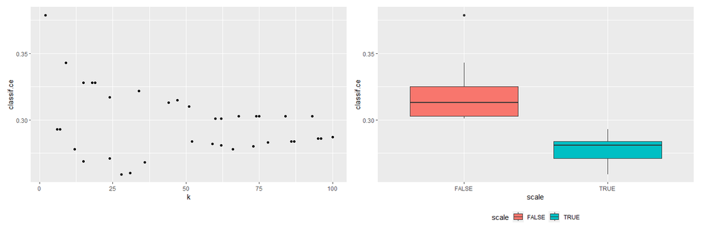

```r
arx = as.data.table(instance$archive)

library(ggplot2)
library(patchwork)

gg_k = ggplot(arx, aes(x = k, y = classif.ce)) + geom_point()
gg_scale = ggplot(arx, aes(x = scale, y = classif.ce, fill = scale)) + geom_boxplot()

gg_k + gg_scale & theme(legend.position = "bottom")
```

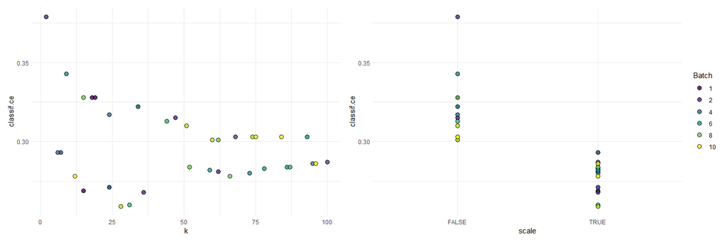

```r
## ALTERNATIVE:

# The `mlr3viz` automatically creates plots for getting an idea of the
# effect of the HPs:

library(mlr3viz)

autoplot(instance)
```

The number of neighbours `k` and `scale` seem to have a big impact on the performance of the model.

# Summary

# Further information

Other (more advanced) tuning algorithms:

- `Simuated annealing`: Random HPC are sampled and accepted based on an acceptance probability function which states how likely an improvement in performance is. The method is implemented in `tnr("gensa")`.
- `Model-based optimization (MBO)`: Guess the most promising HPC by estimating the expected improvement of new points. Available in [`mlr3mbo`](https://mlr3mbo.mlr-org.com/).
- `Multifidelity optimization/Successive halving algorithm`: This technique starts with multiple HPC and throws away unpromising candidates. This is repeated several times to efficiently use the tuning budget. The method is implemented in [`mlr3hyperband`](https://mlr3hyperband.mlr-org.com/).